# Classify different data sets

### Basic includes

```python
# Using pandas to load the csv file
import pandas as pd

import numpy as np
import matplotlib.pyplot as plt

from keras import models
from keras import optimizers
from keras import layers
from keras import callbacks
from keras.utils import to_categorical

# reuters and fashin mnist data set from keras
from keras.datasets import reuters
from keras.datasets import fashion_mnist

# needed to preprocess text
from keras.preprocessing.text import Tokenizer
```

### Classify the Fashion Mnist

```
(60000, 28, 28)
```

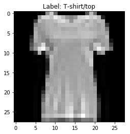

```python
#Get data
(fashion_train_data_raw, fashion_train_labels_raw), (fashion_test_data_raw, fashion_test_labels_raw) = fashion_mnist.load_data()

# These are the real labels, for display purposes only
label_names = [
    'T-shirt/top',
    'Trouser',
    'Pullover',
    'Dress',
    'Coat',
    'Sandal',
    'Shirt',
    'Sneaker',
    'Bag',
    'Ankle boot',
]

# Let's see the size
print(fashion_train_data_raw.shape)


# Now print a sample!
test_index = 10

plt.title("Label: " + label_names[fashion_train_labels_raw[test_index]])
plt.imshow(fashion_train_data_raw[test_index], cmap="gray")
```

### Prepare data

```python
# Reshaping to 1D array
fashion_train_data = fashion_train_data_raw.reshape((fashion_train_data_raw.shape[0], 28*28))/255
fashion_test_data  = fashion_test_data_raw.reshape((fashion_test_data_raw.shape[0], 28*28))/255

# One hot encodings
fashion_train_labels = to_categorical(fashion_train_labels_raw)
fashion_test_labels  = to_categorical(fashion_test_labels_raw)
```

```python
# Model Architecture
fashion_network = models.Sequential()
fashion_network.add(layers.Dense(2048, activation='relu', input_shape=(28 * 28,)))
fashion_network.add(layers.Dropout(0.3))
fashion_network.add(layers.Dense(128, activation='relu'))
fashion_network.add(layers.Dropout(0.3))
fashion_network.add(layers.Dense(10, activation='softmax'))

fashion_network.compile(optimizer='adam', loss='categorical_crossentropy', metrics=['accuracy'])

fashion_network.summary()
```

```
_________________________________________________________________
Layer (type)                 Output Shape              Param #
=================================================================
dense_1 (Dense)              (None, 2048)              1607680
_________________________________________________________________
dropout_1 (Dropout)          (None, 2048)              0
_________________________________________________________________
dense_2 (Dense)              (None, 128)               262272
_________________________________________________________________
dropout_2 (Dropout)          (None, 128)               0
_________________________________________________________________
dense_3 (Dense)              (None, 10)                1290
=================================================================
Total params: 1,871,242
Trainable params: 1,871,242
Non-trainable params: 0
_________________________________________________________________
```

```python
early_stop = callbacks.EarlyStopping(monitor='val_loss', patience=5)
```

```python
# Training
history = fashion_network.fit(
    fashion_train_data,
    fashion_train_labels,
    batch_size=6000,
    epochs=200,
    validation_split=0.2,
    callbacks=[early_stop],
    #verbose=2
)
```

```
Train on 48000 samples, validate on 12000 samples
```

```python
# Evaluate againt test dataset
results = fashion_network.evaluate(fashion_test_data, fashion_test_labels)
print(results)
print(f"Accuracy: {'{0:.2f}'.format(results[1]*100)}%")
```

```
[0.3040671639204025, 0.8961]
Accuracy: 89.61%
```

```
dict_keys(['val_loss', 'val_acc', 'loss', 'acc'])
```

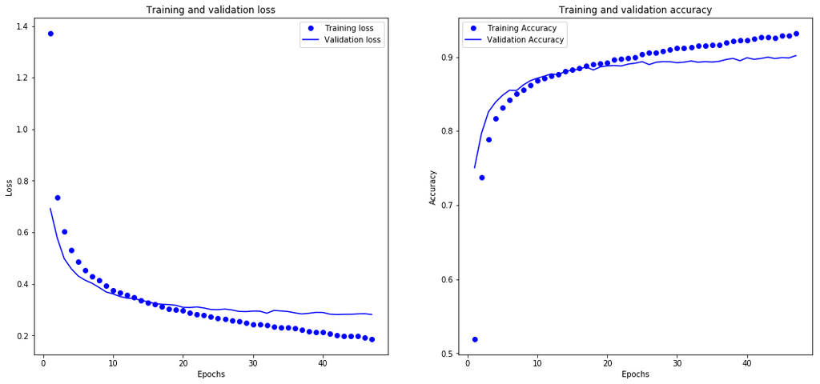

```python
# Make Loss and Acc plots
history_dict = history.history
print(history_dict.keys())
acc = history_dict['acc']
val_acc = history_dict['val_acc']
loss = history_dict['loss']
val_loss = history_dict['val_loss']

epochs = range(1, len(acc) + 1)

f, (ax_loss, ax_acc) = plt.subplots(1,2, figsize=(18,8))

ax_loss.plot(epochs, loss, 'bo', label='Training loss')
ax_loss.plot(epochs, val_loss, 'b', label='Validation loss')
ax_loss.set_title('Training and validation loss')
ax_loss.set_xlabel('Epochs')
ax_loss.set_ylabel('Loss')
ax_loss.legend()

ax_acc.plot(epochs, acc, 'bo', label='Training Accuracy')
ax_acc.plot(epochs, val_acc, 'b', label='Validation Accuracy')
ax_acc.set_title('Training and validation accuracy')
ax_acc.set_xlabel('Epochs')
ax_acc.set_ylabel('Accuracy')
ax_acc.legend()

plt.show()
```

### Prediction example

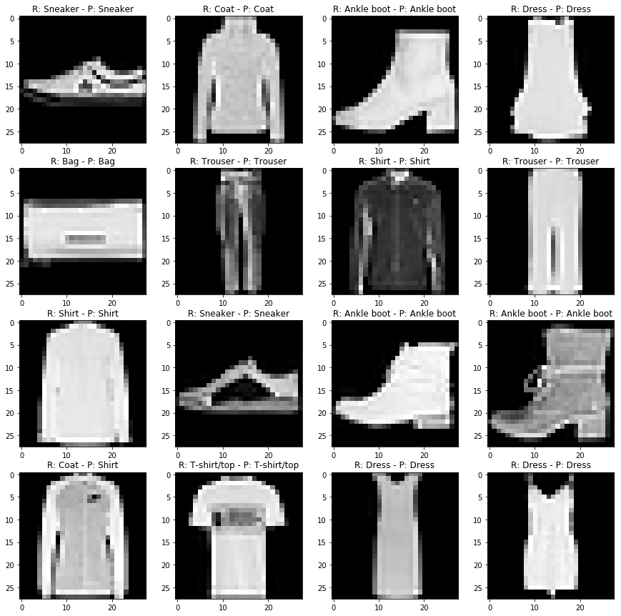

```python
import random
predict_indexes = [random.randint(0, fashion_test_data.shape[0]) for _ in range(16)]
predict_data = np.array([fashion_test_data[i] for i in predict_indexes])
predictions = fashion_network.predict(predict_data)
predictions = np.argmax(predictions, axis=1)

f, plots = plt.subplots(4,4, figsize=(15,15))

for index, prediction, plot in zip(predict_indexes, predictions, plots.flatten()):
    real = fashion_test_labels_raw[index]
    plot.set_title(f"R: {label_names[real]} - P: {label_names[int(prediction)]}")
    plot.imshow(fashion_test_data_raw[index], cmap='gray')
```

### Final Thoughts

This model was faily simple to train, the extensive dataset is certainly a key factor for this. There's a moderately healthy ratio between the dataset size and number of inputs and classes. I started with a model similar to the ones I've seen to be successfull for MNIST since on principle both datasets are very similar, however, I slowly migrated to a model that is heavy on the input and lighter towards the output, I *suppose* this structure might promote recognition of a lot of patterns, which are then correlated in further layers to finally be narrowed down to the output classes, however, this is just a *possible* explanation of why this appears to work. I the end, I have a 784>2048>128>10 architecture trained to produce a 89.61% accuracy with the test dataset.

#### TO DO: Preprocess the data

1. Normalize the input data set
2. Perform one hot encoding
3. Create a train, test, and validation set

#### TO DO: Define and train a network, then plot the accuracy of the training, validation, and testing

1. Use a validation set
2. Propose and train a network
3. Print the history of the training
4. Evaluate with a test set

## Classifying newswires

Build a network to classify Reuters newswires into 46 different mutually-exclusive topics.

### Load and review the data

```python
# Skip the N most common words that might not mean much
skip_first = 150

# How many words to take
num_words  = 2000

(reuters_train_data_raw, reuters_train_labels_raw), \
    (reuters_test_data_raw, reuters_test_labels_raw) = \
    reuters.load_data(
        num_words=num_words,
        test_split=0.1,
        skip_top=skip_first
    )

print(reuters_train_data_raw.shape)
print(reuters_train_labels_raw.shape)
print(reuters_train_data_raw[0])
print(reuters_train_labels_raw[0])

print(set(reuters_train_labels_raw))
```

```
(10105,)
(10105,)
[2, 2, 2, 2, 2, 2, 447, 2, 2, 207, 270, 2, 2, 2, 2, 369, 186, 2, 2, 2, 2, 2, 2, 2, 2, 2, 2, 2, 2, 2, 2, 2, 482, 2, 2, 2, 2, 2, 2, 864, 2, 209, 154, 2, 151, 2, 2, 2, 2, 2, 155, 2, 2, 2, 2, 2, 2, 1005, 504, 2, 258, 2, 272, 2, 2, 2, 2, 2, 2, 2, 2, 2, 197, 1245, 2, 2, 2, 2, 209, 2, 2, 2, 2, 2, 2, 2, 2]
3
{0, 1, 2, 3, 4, 5, 6, 7, 8, 9, 10, 11, 12, 13, 14, 15, 16, 17, 18, 19, 20, 21, 22, 23, 24, 25, 26, 27, 28, 29, 30, 31, 32, 33, 34, 35, 36, 37, 38, 39, 40, 41, 42, 43, 44, 45}
```

Load the word index to decode the train data.

```python
word_index = reuters.get_word_index()

reverse_index = {value+3:key for key, value in word_index.items()}
print(len(reverse_index))
## Let's have a look at the first common words, maybe they're useless
#print(sorted([(k,v) for k,v in reverse_index.items()], key=lambda x:x[0])[:200])

reverse_index[0] = "<PAD>"
reverse_index[1] = "<START>"
reverse_index[2] = "<UNKNOWN>"  # unknown
reverse_index[3] = "<UNUSED>"

# We're only showing the words that will actually make it to the NN
decoded_review = ' '.join([reverse_index.get(i,'?') for i in reuters_train_data_raw[0] if i > 3])

print(decoded_review)
```

```
30979
result december acquisition expects earnings 70 pretax should rise nine six operation revenues 19 22 cash flow should
```

```python
# Tokenize the word sequences into matrices
tokenizer = Tokenizer(num_words=num_words)
reuters_train_data_token = tokenizer.sequences_to_matrix(reuters_train_data_raw, mode='binary')
reuters_test_data_token = tokenizer.sequences_to_matrix(reuters_test_data_raw, mode='binary')
print(reuters_train_data_token.shape)
print(reuters_test_data_token.shape)
```

```
(10105, 2000)
(1123, 2000)
```

```python
# One hot encoding
reuters_one_hot_train_labels = to_categorical(reuters_train_labels_raw)
reuters_one_hot_test_labels = to_categorical(reuters_test_labels_raw)
print(reuters_one_hot_train_labels.shape)
print(reuters_one_hot_test_labels.shape)
```

```
(10105, 46)
(1123, 46)
```

```python
# Model Architecture
reuters_model = models.Sequential()
reuters_model.add(layers.Dense(2048, activation='relu', input_dim=num_words))
reuters_model.add(layers.Dropout(0.8))
reuters_model.add(layers.Dense(2048, activation='relu'))
reuters_model.add(layers.Dropout(0.5))
reuters_model.add(layers.Dense(46, activation='softmax'))
reuters_model.compile(optimizer='sgd', loss='categorical_crossentropy', metrics=['accuracy'])
reuters_model.summary()
```

```
_________________________________________________________________
Layer (type)                 Output Shape              Param #
=================================================================
dense_4 (Dense)              (None, 2048)              4098048
_________________________________________________________________
dropout_3 (Dropout)          (None, 2048)              0
_________________________________________________________________
dense_5 (Dense)              (None, 2048)              4196352
_________________________________________________________________
dropout_4 (Dropout)          (None, 2048)              0
_________________________________________________________________
dense_6 (Dense)              (None, 46)                94254
=================================================================
Total params: 8,388,654
Trainable params: 8,388,654
Non-trainable params: 0
_________________________________________________________________
```

```python
early_stop = callbacks.EarlyStopping(monitor='val_loss', patience=5)
```

```python
# Training
history = reuters_model.fit(
    reuters_train_data_token,
    reuters_one_hot_train_labels,
    #batch_size=4096,
    epochs=30,
    validation_split=0.1,
    callbacks=[early_stop],
    verbose=1
)
```

```
Train on 9094 samples, validate on 1011 samples
```

```python
# Evaluate againt test dataset
results = reuters_model.evaluate(reuters_test_data_token, reuters_one_hot_test_labels)
print(results)
print(f"Accuracy: {'{0:.2f}'.format(results[1]*100)}%")
```

```
[1.044580147187835, 0.7711487088422104]
Accuracy: 77.11%
```

```
dict_keys(['val_loss', 'val_acc', 'loss', 'acc'])
```

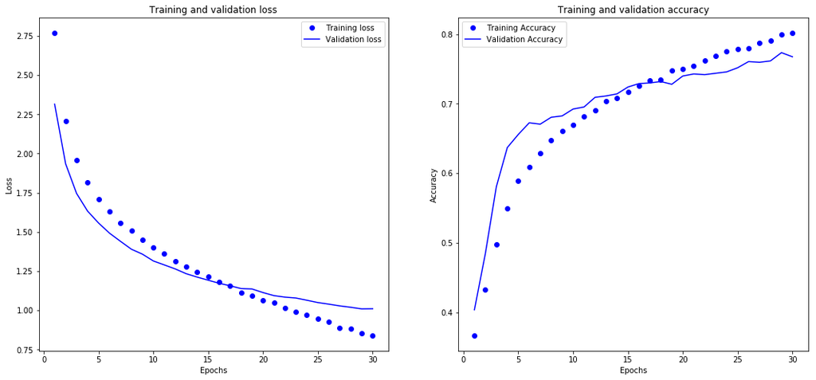

```python
# Make Loss and Acc plots
history_dict = history.history
print(history_dict.keys())
acc = history_dict['acc']
val_acc = history_dict['val_acc']
loss = history_dict['loss']
val_loss = history_dict['val_loss']

epochs = range(1, len(acc) + 1)

f, (ax_loss, ax_acc) = plt.subplots(1,2, figsize=(18,8))

ax_loss.plot(epochs, loss, 'bo', label='Training loss')
ax_loss.plot(epochs, val_loss, 'b', label='Validation loss')
ax_loss.set_title('Training and validation loss')
ax_loss.set_xlabel('Epochs')
ax_loss.set_ylabel('Loss')
ax_loss.legend()

ax_acc.plot(epochs, acc, 'bo', label='Training Accuracy')
ax_acc.plot(epochs, val_acc, 'b', label='Validation Accuracy')
ax_acc.set_title('Training and validation accuracy')
ax_acc.set_xlabel('Epochs')
ax_acc.set_ylabel('Accuracy')
ax_acc.legend()

plt.show()
```

### Predictions example

```python
import random
predict_indexes = [random.randint(0, reuters_test_data_raw.shape[0]) for _ in range(5)]
predict_data = np.array([reuters_test_data_token[i] for i in predict_indexes])
predictions = reuters_model.predict(predict_data)
predictions = np.argmax(predictions, axis=1)

ok = 0
for index, prediction in zip(predict_indexes, predictions):
    real = reuters_test_labels_raw[index]
    ok += 1 if real == prediction else 0
    print(f"Prediction:\nReal:{real} - Predicted: {prediction}")
    print(' '.join([reverse_index.get(i,'?') for i in reuters_train_data_raw[index][:30] if i > 3]) + "...")

print(f"\nAccuracy for the samples: {'{0:.2f}'.format(100*ok/float(len(predict_indexes)))}%")
```

```
Prediction:
Real:13 - Predicted: 13
gross domestic product growth likely between head official institute economic...
Prediction:
Real:19 - Predicted: 19
court decision law aimed companies out state businesses high...
Prediction:
Real:3 - Predicted: 3
general completed purchase products department air products chemicals terms disclosed department makes...
Prediction:
Real:13 - Predicted: 13
99 given given nine mths 35 given given...
Prediction:
Real:4 - Predicted: 4
brazilian workers voted strike labour failure government's anti inflation plan...

Accuracy for the samples: 100.00%
```

### Final Thoughts

Given the complexity of the data and the grat number of classes I felt it necessary to try a big network, after trying several combinations 2048 seemed the best number for which the increase in complexity yielded sufficient improvement to be worth it.

#### TO DO: Preprocess the data

1. Normalize the input data set
2. Perform one hot encoding
3. Create a train, test, and validation set

#### TO DO: Define and train a network, then plot the accuracy of the training, validation, and testing

1. Use a validation set
2. Propose and train a network
3. Print the history of the training
4. Evaluate with a test set

## Predicting Student Admissions

Predict student admissions based on three pieces of data:

- GRE Scores
- GPA Scores
- Class rank

### Load and visualize the data

```python
student_data = pd.read_csv("student_data.csv")
print(student_data)
```

```
     admit  gre   gpa  rank
0        0  380  3.61     3
1        1  660  3.67     3
2        1  800  4.00     1
3        1  640  3.19     4
4        0  520  2.93     4
5        1  760  3.00     2
6        1  560  2.98     1
7        0  400  3.08     2
8        1  540  3.39     3
9        0  700  3.92     2
10       0  800  4.00     4
11       0  440  3.22     1
12       1  760  4.00     1
13       0  700  3.08     2
```

[output cut: 49 more lines]

Plot of the GRE and the GPA from the data.

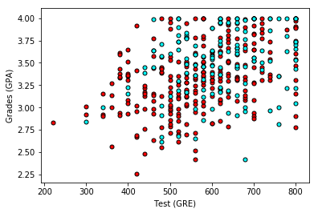

```python
X = np.array(student_data[["gre","gpa"]])
y = np.array(student_data["admit"])
admitted = X[np.argwhere(y==1)]
rejected = X[np.argwhere(y==0)]
plt.scatter([s[0][0] for s in rejected], [s[0][1] for s in rejected], s = 25, color = 'red', edgecolor = 'k')
plt.scatter([s[0][0] for s in admitted], [s[0][1] for s in admitted], s = 25, color = 'cyan', edgecolor = 'k')
plt.xlabel('Test (GRE)')
plt.ylabel('Grades (GPA)')

plt.show()
```

Plot of the data by class rank.

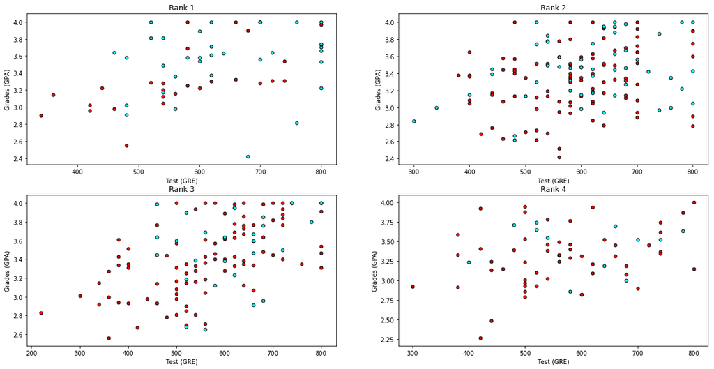

```python
f, plots = plt.subplots(2, 2, figsize=(20,10))
plots = [plot for sublist in plots for plot in sublist]

for idx, plot in enumerate(plots):
    data_rank = student_data[student_data["rank"]==idx+1]
    plot.set_title("Rank " + str(idx+1))
    X = np.array(data_rank[["gre","gpa"]])
    y = np.array(data_rank["admit"])
    admitted = X[np.argwhere(y==1)]
    rejected = X[np.argwhere(y==0)]
    plot.scatter([s[0][0] for s in rejected], [s[0][1] for s in rejected], s = 25, color = 'red', edgecolor = 'k')
    plot.scatter([s[0][0] for s in admitted], [s[0][1] for s in admitted], s = 25, color = 'cyan', edgecolor = 'k')
    plot.set_xlabel('Test (GRE)')
    plot.set_ylabel('Grades (GPA)')
```

```python
# Normalize both GPA and GRE usig a normal distribution
gpa_mean = student_data['gpa'].mean()
gpa_stdv = student_data['gpa'].std()

gre_mean = student_data['gre'].mean()
gre_stdv = student_data['gre'].std()

student_data['gpa'] -= gpa_mean
student_data['gpa'] /= gpa_stdv

student_data['gre'] -= gre_mean
student_data['gre'] /= gre_stdv
```

```python
# Create a copy of the array
student_values = student_data.values
# Shuffle the new array
np.random.shuffle(student_values)

# Separate GRE and GPA
s_data = student_values[:,1:3]
# Convert the rank into classes
ranks = to_categorical(student_values[:,3]-1)
# Joing GRE, GPA and rank classes
s_data = np.concatenate((s_data, ranks), axis=1)

# One hot labels
s_labels = to_categorical(student_values[:,0:1])


print(s_data.shape)
print(s_labels.shape)
```

```
(397, 6)
(397, 2)
```

```python
# Ratio for test dataset separation
test_ratio = 0.20

# Separate train and test datasets
threshold = round(s_data.shape[0] * test_ratio)
s_train_data, s_train_labels = s_data[:s_data.shape[0]-threshold], s_labels[:s_data.shape[0]-threshold]
s_test_data, s_test_labels = s_data[-threshold:], s_labels[-threshold:]

print(s_train_data.shape, s_train_labels.shape)
print(s_test_data.shape, s_test_labels.shape)
```

```
(318, 6) (318, 2)
(79, 6) (79, 2)
```

```python
# Model Architecture
students_model = models.Sequential()
students_model.add(layers.Dense(4, activation='relu', input_dim=s_data.shape[1]))
students_model.add(layers.Dropout(0.1))
students_model.add(layers.Dense(2, activation='softmax'))
students_model.compile(optimizer='adam', loss='binary_crossentropy', metrics=['accuracy'])
students_model.summary()
```

```
_________________________________________________________________
Layer (type)                 Output Shape              Param #
=================================================================
dense_7 (Dense)              (None, 4)                 28
_________________________________________________________________
dropout_5 (Dropout)          (None, 4)                 0
_________________________________________________________________
dense_8 (Dense)              (None, 2)                 10
=================================================================
Total params: 38
Trainable params: 38
Non-trainable params: 0
_________________________________________________________________
```

```python
early_stop = callbacks.EarlyStopping(monitor='val_loss', patience=20)
```

```python
# Training
history = students_model.fit(
    s_train_data, s_train_labels,
    #batch_size=10000,
    epochs=500,
    validation_split=0.3,
    callbacks=[early_stop],
    verbose=2
)
```

```
Train on 222 samples, validate on 96 samples
 - 0s - loss: 0.7170 - acc: 0.5068 - val_loss: 0.7604 - val_acc: 0.3542
 - 0s - loss: 0.7125 - acc: 0.5045 - val_loss: 0.7519 - val_acc: 0.3646
 - 0s - loss: 0.7088 - acc: 0.5405 - val_loss: 0.7431 - val_acc: 0.3958
 - 0s - loss: 0.7044 - acc: 0.5450 - val_loss: 0.7353 - val_acc: 0.4167
 - 0s - loss: 0.6984 - acc: 0.5721 - val_loss: 0.7274 - val_acc: 0.4167
 - 0s - loss: 0.6956 - acc: 0.5721 - val_loss: 0.7198 - val_acc: 0.4375
 - 0s - loss: 0.6797 - acc: 0.5946 - val_loss: 0.7129 - val_acc: 0.4896
 - 0s - loss: 0.6766 - acc: 0.6036 - val_loss: 0.7062 - val_acc: 0.4896
 - 0s - loss: 0.6765 - acc: 0.5946 - val_loss: 0.7004 - val_acc: 0.5312
 - 0s - loss: 0.6743 - acc: 0.6036 - val_loss: 0.6945 - val_acc: 0.5625
 - 0s - loss: 0.6650 - acc: 0.6351 - val_loss: 0.6888 - val_acc: 0.5729
 - 0s - loss: 0.6648 - acc: 0.6351 - val_loss: 0.6838 - val_acc: 0.5938
 - 0s - loss: 0.6591 - acc: 0.6532 - val_loss: 0.6789 - val_acc: 0.6250
 - 0s - loss: 0.6553 - acc: 0.6396 - val_loss: 0.6743 - val_acc: 0.6458
 - 0s - loss: 0.6565 - acc: 0.6486 - val_loss: 0.6700 - val_acc: 0.6562
 - 0s - loss: 0.6503 - acc: 0.6532 - val_loss: 0.6658 - val_acc: 0.6458
 - 0s - loss: 0.6559 - acc: 0.6441 - val_loss: 0.6617 - val_acc: 0.6667
 - 0s - loss: 0.6484 - acc: 0.6577 - val_loss: 0.6583 - val_acc: 0.6667
 - 0s - loss: 0.6393 - acc: 0.6712 - val_loss: 0.6549 - val_acc: 0.6875
 - 0s - loss: 0.6391 - acc: 0.6667 - val_loss: 0.6516 - val_acc: 0.6979
 - 0s - loss: 0.6383 - acc: 0.6667 - val_loss: 0.6484 - val_acc: 0.6979
 - 0s - loss: 0.6327 - acc: 0.6802 - val_loss: 0.6451 - val_acc: 0.6979
 - 0s - loss: 0.6369 - acc: 0.6667 - val_loss: 0.6423 - val_acc: 0.6979
 - 0s - loss: 0.6326 - acc: 0.6757 - val_loss: 0.6391 - val_acc: 0.6979
 - 0s - loss: 0.6334 - acc: 0.6712 - val_loss: 0.6365 - val_acc: 0.6979
 - 0s - loss: 0.6351 - acc: 0.6712 - val_loss: 0.6344 - val_acc: 0.6979
 - 0s - loss: 0.6278 - acc: 0.6712 - val_loss: 0.6321 - val_acc: 0.6979
 - 0s - loss: 0.6338 - acc: 0.6712 - val_loss: 0.6301 - val_acc: 0.6979
 - 0s - loss: 0.6342 - acc: 0.6712 - val_loss: 0.6285 - val_acc: 0.6979
 - 0s - loss: 0.6244 - acc: 0.6802 - val_loss: 0.6265 - val_acc: 0.6979
 - 0s - loss: 0.6206 - acc: 0.6712 - val_loss: 0.6252 - val_acc: 0.6979
 - 0s - loss: 0.6175 - acc: 0.6757 - val_loss: 0.6234 - val_acc: 0.6979
 - 0s - loss: 0.6193 - acc: 0.6712 - val_loss: 0.6220 - val_acc: 0.6979
 - 0s - loss: 0.6193 - acc: 0.6757 - val_loss: 0.6206 - val_acc: 0.6979
 - 0s - loss: 0.6271 - acc: 0.6667 - val_loss: 0.6192 - val_acc: 0.6979
 - 0s - loss: 0.6064 - acc: 0.6757 - val_loss: 0.6176 - val_acc: 0.6979
 - 0s - loss: 0.6122 - acc: 0.6712 - val_loss: 0.6159 - val_acc: 0.6979
 - 0s - loss: 0.6145 - acc: 0.6802 - val_loss: 0.6148 - val_acc: 0.6979
 - 0s - loss: 0.6144 - acc: 0.6847 - val_loss: 0.6134 - val_acc: 0.6979
```

[output cut: 23 more lines]

```
 - 0s - loss: 0.5873 - acc: 0.7297 - val_loss: 0.6045 - val_acc: 0.6875
 - 0s - loss: 0.5910 - acc: 0.7252 - val_loss: 0.6047 - val_acc: 0.6875
 - 0s - loss: 0.5827 - acc: 0.7342 - val_loss: 0.6049 - val_acc: 0.6875
 - 0s - loss: 0.5785 - acc: 0.7342 - val_loss: 0.6050 - val_acc: 0.6875
 - 0s - loss: 0.5852 - acc: 0.7342 - val_loss: 0.6050 - val_acc: 0.6875
 - 0s - loss: 0.5927 - acc: 0.7072 - val_loss: 0.6052 - val_acc: 0.6875
 - 0s - loss: 0.5805 - acc: 0.7297 - val_loss: 0.6056 - val_acc: 0.6875
 - 0s - loss: 0.5939 - acc: 0.7207 - val_loss: 0.6058 - val_acc: 0.6875
 - 0s - loss: 0.5895 - acc: 0.7252 - val_loss: 0.6060 - val_acc: 0.6875
 - 0s - loss: 0.5853 - acc: 0.7162 - val_loss: 0.6062 - val_acc: 0.6875
 - 0s - loss: 0.5760 - acc: 0.7342 - val_loss: 0.6063 - val_acc: 0.6979
 - 0s - loss: 0.5785 - acc: 0.7342 - val_loss: 0.6063 - val_acc: 0.6979
 - 0s - loss: 0.5827 - acc: 0.7342 - val_loss: 0.6064 - val_acc: 0.6875
 - 0s - loss: 0.5858 - acc: 0.7207 - val_loss: 0.6065 - val_acc: 0.6875
 - 0s - loss: 0.5792 - acc: 0.7297 - val_loss: 0.6066 - val_acc: 0.6875
```

```python
# Evaluate againt test dataset
results = students_model.evaluate(s_test_data, s_test_labels)
print(results)
print(f"Accuracy: {'{0:.2f}'.format(results[1]*100)}%")
```

```
[0.5743917943556097, 0.7341772189623192]
Accuracy: 73.42%
```

```
dict_keys(['val_loss', 'val_acc', 'loss', 'acc'])
```

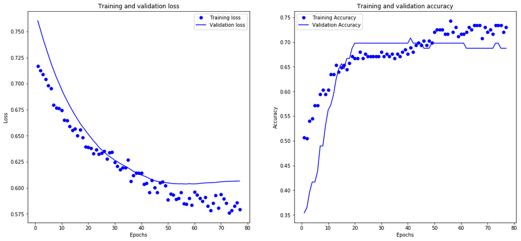

```python
# Make Loss and Acc plots
history_dict = history.history
print(history_dict.keys())
acc = history_dict['acc']
val_acc = history_dict['val_acc']
loss = history_dict['loss']
val_loss = history_dict['val_loss']

epochs = range(1, len(acc) + 1)

f, (ax_loss, ax_acc) = plt.subplots(1,2, figsize=(18,8))

ax_loss.plot(epochs, loss, 'bo', label='Training loss')
ax_loss.plot(epochs, val_loss, 'b', label='Validation loss')
ax_loss.set_title('Training and validation loss')
ax_loss.set_xlabel('Epochs')
ax_loss.set_ylabel('Loss')
ax_loss.legend()

ax_acc.plot(epochs, acc, 'bo', label='Training Accuracy')
ax_acc.plot(epochs, val_acc, 'b', label='Validation Accuracy')
ax_acc.set_title('Training and validation accuracy')
ax_acc.set_xlabel('Epochs')
ax_acc.set_ylabel('Accuracy')
ax_acc.legend()

plt.show()
```

#### TO DO: Preprocess the data

1. Normalize the input data set
2. Perform one hot encoding
3. Create a train, test, and validation set

#### TO DO: Define and train a network, then plot the accuracy of the training, validation, and testing

1. Use a validation set
2. Propose and train a network
3. Print the history of the training
4. Evaluate with a test set

### Prediction examples

```python
import random
predict_indexes = [random.randint(0, s_test_data.shape[0]-1) for _ in range(5)]
predict_data = np.array([s_test_data[i] for i in predict_indexes])
predictions = students_model.predict(predict_data)
predictions = np.argmax(predictions, axis=1)

ok = 0
for index, prediction in zip(predict_indexes, predictions):
    predicition = np.argmax(prediction)
    real = np.argmax(s_test_labels[index])
    ok += 1 if real == prediction else 0
    print(f"Real: {real} - Predicted: {prediction}")
    print(f"GPA: {'{0:.2f}'.format(s_test_data[index][0]*gpa_stdv + gpa_mean)}")
    print(f"GRE: {'{0:.2f}'.format(s_test_data[index][1]*gre_stdv + gre_mean)}")
    print(f"Rank: {np.argmax(s_test_data[index][2:])+1}\n")

print(f"\nAccuracy for the samples: {'{0:.2f}'.format(100*ok/float(len(predict_indexes)))}%")
```

```
Real: 0 - Predicted: 0
GPA: 3.10
GRE: 462.39
Rank: 3

Real: 1 - Predicted: 0
GPA: 3.76
GRE: 638.92
Rank: 2

Real: 0 - Predicted: 0
GPA: 3.10
GRE: 477.61
Rank: 3

Real: 1 - Predicted: 1
GPA: 4.09
GRE: 681.53
Rank: 1

Real: 0 - Predicted: 0
GPA: 3.30
GRE: 322.39
Rank: 2


Accuracy for the samples: 80.00%
```

### Final Thoughts

In the end, I found out that given the small size of the dataset, aiming for smaller networks yielded the best results.